# Spatial synchrony of grassland birds

Mike Allen

November 22, 2019

# About

This code summarizes route-level Breeding Bird Survey data into 2x2 degree grid-cells and analyzes spatial synchrony for 19 species of grassland birds. See Links at bottom for data sources, papers, etc.

To do: 1. include raw “inclusion” variables (e.g., num zeros) into the final data ‘outputs’ - that way grid-cells can be excluded as needed on the fly in the final synchrony step without re-running entire code 2. incorporate a re-sampling / montecarlo test for the binned bar graphs and/or maps 3. fix function so it stops saying “Using grid4B ad id variables” and “NAs introduced by coercion”

# Collect and process syncrony data for grassland bird species

All objects from this step are pre-loaded into bbsync.Rdata.

Creates the objects:

1. allsync: Combine function results (pairwise gridcell synchrony) for all species.
2. mapsync: Create moving average of all adjacent cells within 400 km (i.e., all 8 neighbors) for both periods.
3. syncdiff: Calculate change in synchrony between periods for each species/grid cell.
4. meansyncdiff: Calculate mean change in synchrony across all GLB species by grid cell.

These are already pre-loaded in bbsync.Rdata. If needed, run the script “GLB_processing.R” above.

# Number of grid-cell-pair synchrony estimates per species per period

```r
table(allsync$sp, allsync$per)
```

```
##
##        1966-1991 1992-2017
##   GRSP      3566      6441
##   BOBO      3383      4750
##   EAME      7138      7875
##   SAVS      4992     13659
##   NOHA       969      3001
##   UPSA       703      1953
##   LBCU        65       561
##   HOLA      9481     16457
##   HESP         6         6
##   SEWR       136       375
##   SPPI        15        55
##   DICK      1890      2701
##   VESP      5015     10132
##   LARB       276       378
##   BAIS        28        78
##   CASP       125       300
##   LESP        10       245
##   WEME      6515     11898
##   RNEP      4269      6441
##   MCLO         1        28
##   CCLO        91       136
##   STGR         1        36
##   MOPL         1         6
```

# Graph synchrony decay with distance (% positive correlations in distance bins)

See Martin et al.

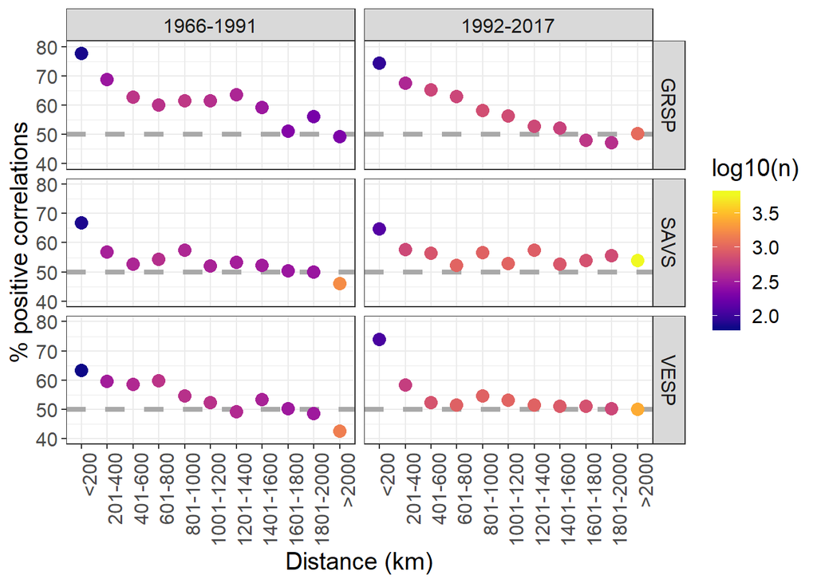

```r
allsync %>%
  mutate(dcat2 = cut(
  allsync$dist,
  c(0, 200, 400, 600, 800, 1000,
  1200, 1400, 1600, 1800, 2000, 100000),
  labels = c(
  "<200",
  "201-400",
  "401-600",
  "601-800",
  "801-1000",
  "1001-1200",
  "1201-1400",
  "1401-1600",
  "1601-1800",
  "1801-2000",
  ">2000"
  )
  )) %>%
  mutate(pos = as.numeric(ifelse(cor > 0, 1, 0))) %>%
  group_by(dcat2, sp, per) %>%
  summarise(
  pctsig = mean(sig1) * 100,
  n = length(pos),
  pctpos = mean(pos) * 100
  ) %>%
  ungroup() %>%
  filter(sp %in% c("GRSP", "VESP", "SAVS"), n >= 50) %>%
  ggplot() +
  geom_abline(
  slope = 0,
  intercept = 50,
  linetype = 2,
  size = 1.5,
  color = "darkgray"
  ) +
  geom_point(aes(y = pctpos, x = dcat2, color = log10(n)), size = 3.5) +
  scale_y_continuous(limits = c(40, 80)) +
  labs(x = "Distance (km)", y = "% positive correlations") +
  theme_bw() +
  facet_grid(rows = vars(sp), cols = vars(per)) +
  theme(text = element_text(size = 15)) +
  theme(axis.text.x = element_text(angle = 90, hjust = 1)) +
  scale_color_viridis(option = "C")
```

```r
  #NEXT: need to create n = 1000 null (random) distributions for each bin like Martin et al. to test spatial extent of synchrony.
```

# Graph synchrony decay with distance (continous)

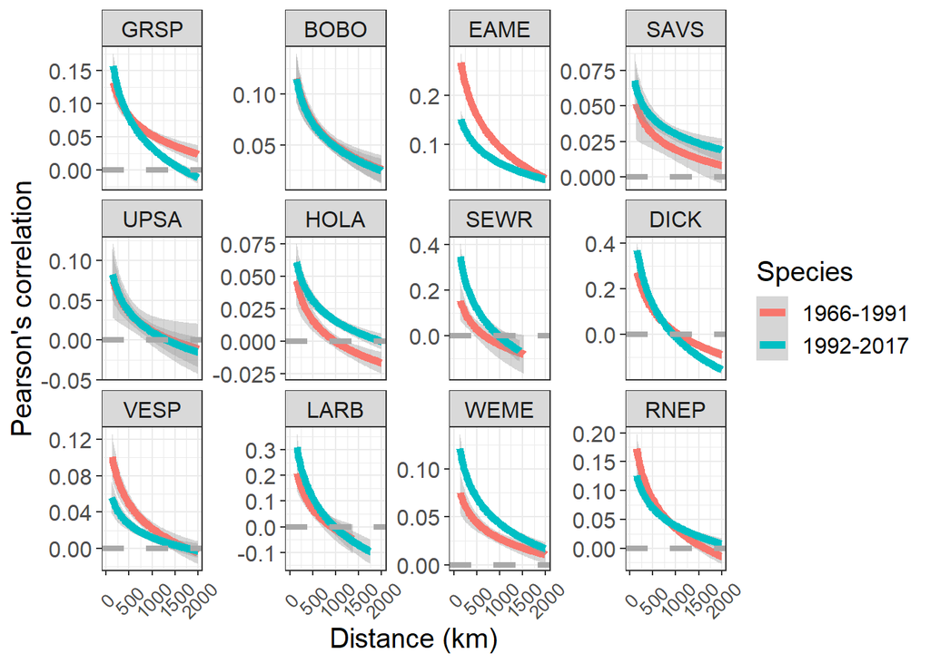

```r
#X11(13,9)
allsync %>%
  filter(sp %in% c("GRSP", "HOLA", "VESP", "SEWR", "EAME", "WEME", "DICK", "BOBO", "UPSA", "SAVS",
                   "LARB", "RNEP")) %>%
  ggplot() +
  geom_smooth(aes(x=dist, y=cor, color = per), size = 2, method="glm", formula = y~log(x), se=T) +
  facet_wrap(~sp, ncol = 4, scales = "free_y") +
  xlim(c(0,2000)) +
  theme_bw() +
  theme(text = element_text(size=15)) +
  theme(axis.text.x = element_text(size=10, angle = 45, vjust = .5)) +
  labs(x = "Distance (km)", y = "Pearson's correlation", linetype = "Period", color = "Species") +
  geom_abline(slope = 0, intercept = 0, color = "darkgray", linetype = 2, size = 1.5)
```

```r
# ggsave("figures/grid4_sync_scatter/EAME.GRSP.BOBO.SAVS_cor_grid4_66.17_no.se_AR_5zeros_n20.jpg")
    # suggestion to use method="auto" as "loess" didn't have enough memory: https://groups.google.com/forum/#!topic/ggplot2/enavD18MmkY
```

# Make a base map of North America

```r
na <- ggplot() +
  borders("world", xlim = c(-150, -60), ylim = c(35, 40), colour = "gray85", fill = "gray80")  +
  borders("state", colour = "gray85", fill = "gray80") +
  geom_polygon(data=canada.fort, aes(x = long, y = lat, group=group), colour = "gray85", fill = "gray80") +
  theme_map() +
  coord_map('albers', lat0=30, lat1=60) #+
  #xlim(c(-150,-60))
```

# Map mean synchrony for all grassland species individually (1992-2017)

Takes a long time.

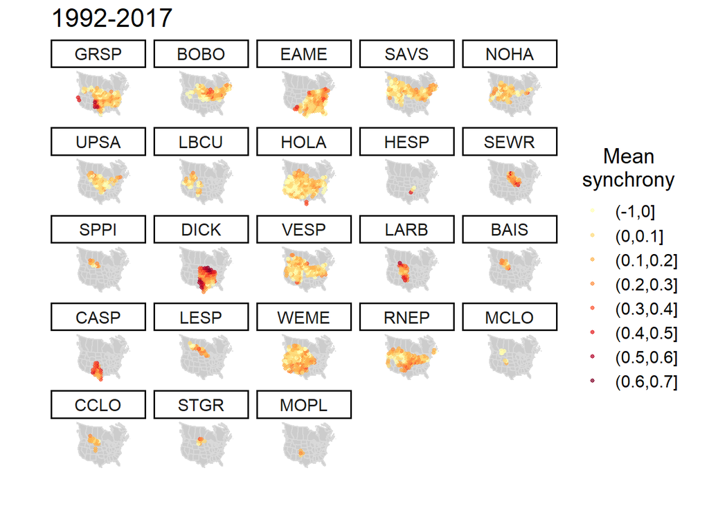

```r
# x11(30,20)
na +
  geom_point(aes(x = grid_lon, y = grid_lat, color = corcat), size = 1, alpha = .7, data = filter(mapsync,per=="1992-2017",grid_lat<=59)) +
  scale_colour_manual(values = c("#ffffb2", "#fed976", "#feb24c", "#fd8d3c", "#fc4e2a", "#e31a1c", "#b10026", "#800026")) +
  theme_classic() +
  theme(text = element_text(size=15)) +
  facet_wrap(~sp) +
  labs(colour="Mean\nsynchrony", x="", y="", title="1992-2017") +
  theme(axis.text.x = element_blank(),  axis.text.y = element_blank(),axis.ticks = element_blank()) +
  theme(legend.title.align=0.5) +
  theme(axis.line = element_line(color = "transparent")) +
  xlim(c(-142,-59))
```

```r
# ggsave("figures/grid4_maps/ALLsp.grid4_92.17_AR_5zeros_n20_60lat.png")
```

# Map mean synchrony for all grassland species individually (1966-1991)

Takes a long time.

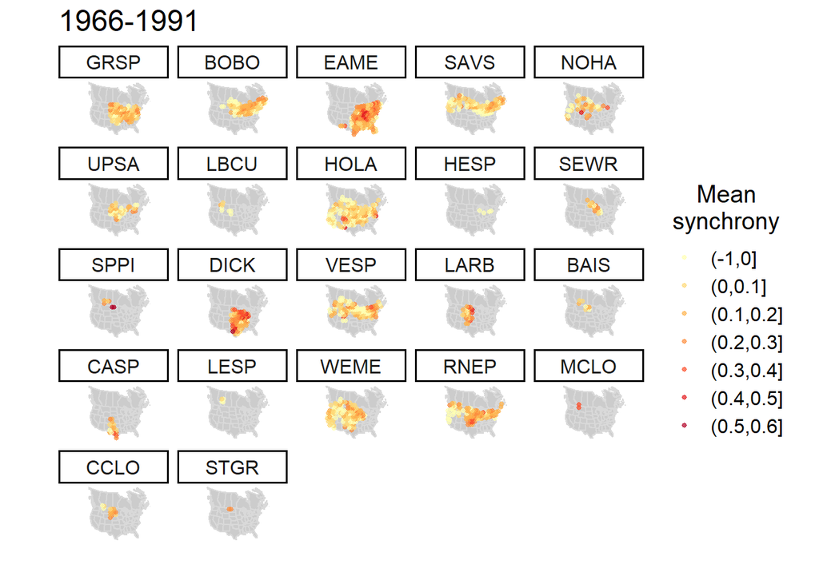

```r
# x11(30,20)
na +
  geom_point(aes(x = grid_lon, y = grid_lat, color = corcat), size = 1, alpha = .7, data = filter(mapsync,per=="1966-1991",grid_lat<=59)) +
  scale_colour_manual(values = c("#ffffb2", "#fed976", "#feb24c", "#fd8d3c", "#fc4e2a", "#e31a1c", "#b10026", "#800026")) +
  theme_classic() +
  theme(text = element_text(size=15)) +
  facet_wrap(~sp) +
  labs(colour="Mean\nsynchrony", x="", y="", title="1966-1991") +
  theme(axis.text.x = element_blank(),  axis.text.y = element_blank(),axis.ticks = element_blank()) +
  theme(legend.title.align=0.5) +
  theme(axis.line = element_line(color = "transparent")) +
  xlim(c(-142,-59))
```

```r
#ggsave("figures/grid4_maps/ALLsp.grid4_66.91_AR_5zeros_n20_60lat.png")
```

# Map mean synchrony for a single species and time period (to make GIFs)

For making GIFs. Make sure scales match between periods.

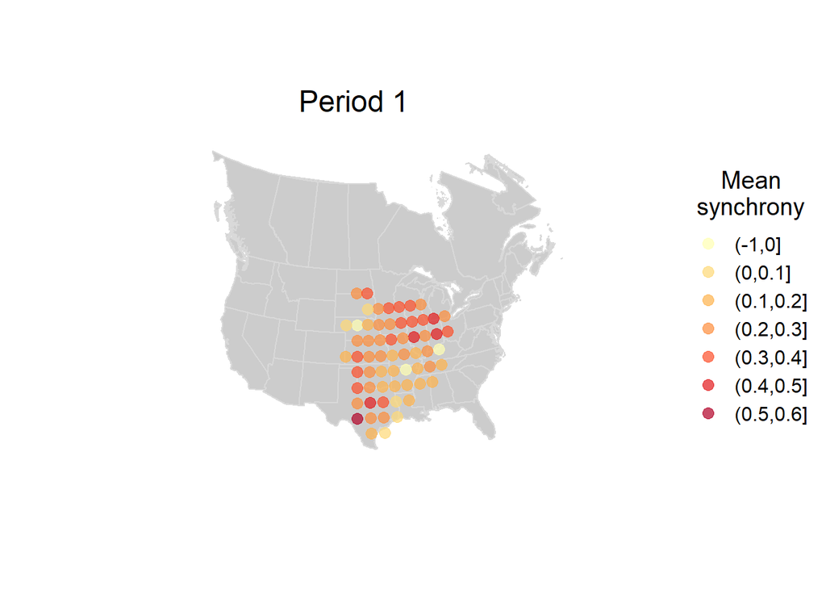

```r
# x11(9,9)
na +
  geom_point(aes(x = grid_lon, y = grid_lat, color = corcat), size = 3, alpha = .7, data = filter(mapsync,per=="1966-1991",grid_lat<=59, sp=="DICK")) +
  scale_colour_manual(values = c("#ffffb2", "#fed976", "#feb24c", "#fd8d3c", "#fc4e2a", "#e31a1c", "#b10026", "#800026")) +
  theme_classic() +
  theme(text = element_text(size=15)) +
  labs(colour="Mean\nsynchrony", x="", y="", title="Period 1") +
  theme(axis.text.x = element_blank(),  axis.text.y = element_blank(),axis.ticks = element_blank()) +
  theme(legend.title.align=0.5) +
  theme(plot.title = element_text(hjust = 0.5)) +
  theme(axis.line = element_line(color = "transparent")) +
  xlim(c(-142,-59)) #+ guides(color=FALSE)
```

```r
#ggsave("figures/grid4_maps/DICKsp.grid4_66.91_AR_5zeros_n20_60lat_nolegend.png")
```

# Map change in synchrony for all species individually (points, categorical)

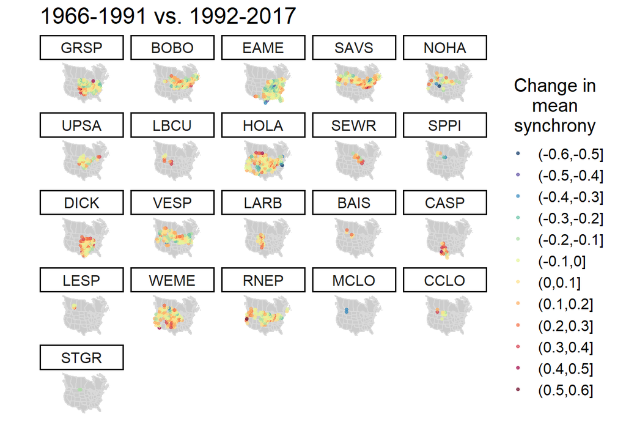

```r
#x11(30,20)
na +
  geom_point(aes(x = grid_lon.x, y = grid_lat.x, color = diffcat), size = 1, alpha = .7, data = syncdiff) +
  scale_colour_manual(values = c("#053061","#5e4fa2","#3288bd","#66c2a5","#abdda4","#e6f598",
                                 "#fee08b","#fdae61","#f46d43","#d53e4f","#9e0142", "#67001f")) +
  theme_classic() +
  theme(text = element_text(size=15)) +
  facet_wrap(~sp.x) +
  labs(colour="Change in\nmean\nsynchrony", x="", y="", title="1966-1991 vs. 1992-2017") +
  theme(axis.text.x = element_blank(),  axis.text.y = element_blank(),axis.ticks = element_blank()) +
  theme(legend.title.align=0.5) +
  theme(axis.line = element_line(color = "transparent")) +
  xlim(c(-142,-59))
```

```r
#ggsave("figures/grid4_maps/ALLsp.grid4_change_AR_5zeros_n20_60lat.png")
```

# Map mean change in synchrony for all species combined (points, categorical)

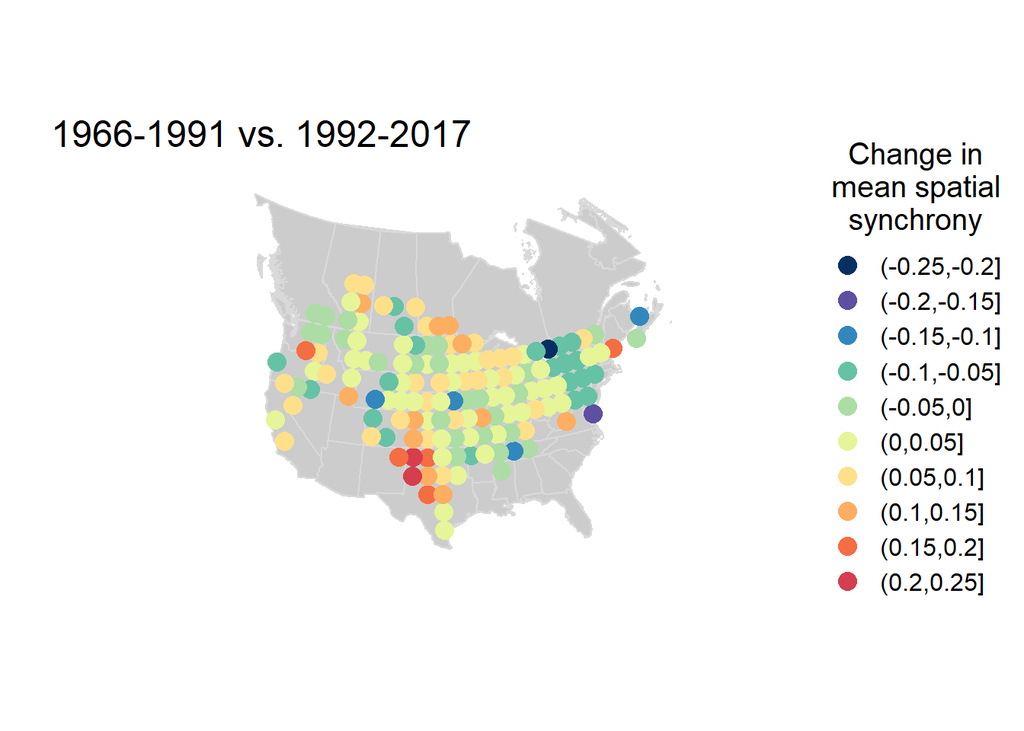

```r
#x11(13,9)
na +
  geom_point(aes(x = grid_lon.x, y = grid_lat.x, color = meandiffcat), size = 4, alpha = 1, data = meansyncdiff) +
  scale_colour_manual(values = c("#053061","#5e4fa2","#3288bd","#66c2a5","#abdda4","#e6f598",
                                 "#fee08b","#fdae61","#f46d43","#d53e4f","#9e0142", "#67001f")) +
  theme_classic() +
  theme(text = element_text(size=15)) +
  labs(colour="Change in\nmean spatial\nsynchrony", x="", y="", title="1966-1991 vs. 1992-2017") +
  theme(axis.text.x = element_blank(),  axis.text.y = element_blank(),axis.ticks = element_blank()) +
  theme(legend.title.align=0.5) +
  theme(axis.line = element_line(color = "transparent")) +
  xlim(c(-142,-59))
```

```r
#ggsave("figures/grid4_maps/Mean.ALLsp.grid4_change_AR_5zeros_n20_60lat.png")
```

# Map mean change in synchrony for all species combined (points, continuous)

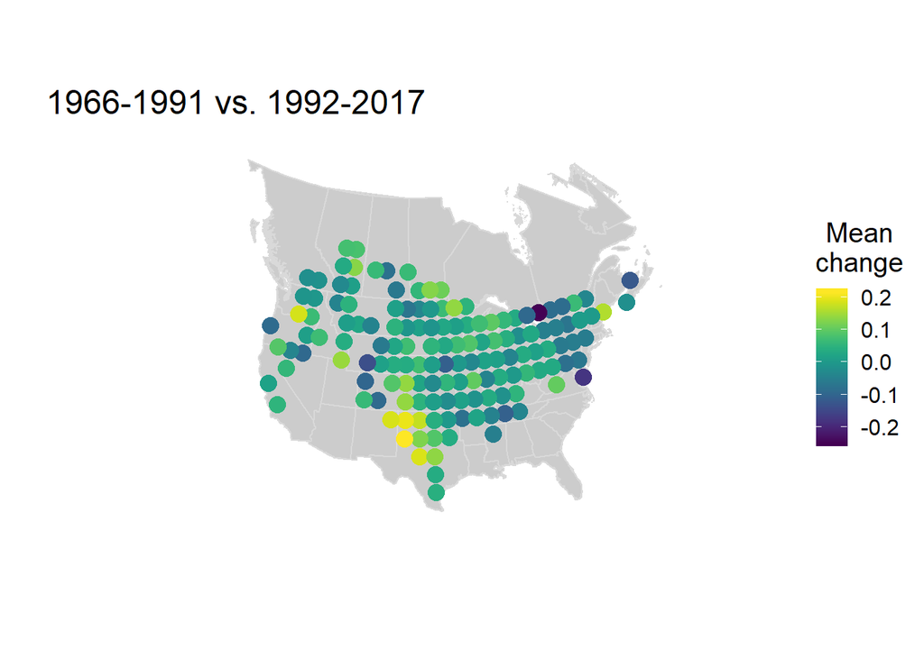

```r
#x11(13,9)
na +
  geom_point(aes(x = grid_lon.x, y = grid_lat.x, color = meansyncdiff), size = 4, alpha = 1, data = meansyncdiff) +
  scale_color_viridis(name = "Mean\nchange", option = "viridis") +
  theme_classic() +
  theme(text = element_text(size=15)) +
  labs(colour="Change in\nmean spatial\nsynchrony", x="", y="", title="1966-1991 vs. 1992-2017") +
  theme(axis.text.x = element_blank(),  axis.text.y = element_blank(),axis.ticks = element_blank()) +
  theme(legend.title.align=0.5) +
  theme(axis.line = element_line(color = "transparent")) +
  xlim(c(-142,-59))
```

```r
#ggsave("figures/grid4_maps/Mean.ALLsp.grid4_change.viridis_AR_5zeros_n20_60lat.png")
```

# Format grid-cell-level synchrony change data for plotting

```r
ridgeplotdata = syncdiff %>%
  select(species = sp.x, syncdiff, incdec, grid_lon.x) %>%
  bind_rows(select(meansyncdiff, species, syncdiff = meansyncdiff, incdec = meanincdec, grid_lon.x)) %>%
  filter(species != "STGR" & species != "MCLO") %>%
  mutate(region = ifelse(grid_lon.x <= -90, "West", "East")) %>%
  group_by(species) %>%
  mutate(medmeandiff = median(syncdiff), n = length(species),
         meanmeandiff = mean(syncdiff), sdmeandiff = sd(syncdiff),
         wtmeandiff = 1/(sdmeandiff^2)) %>%
  ungroup() %>%
  mutate(medmeandiff = as.numeric(ifelse(species == "All species","1",medmeandiff))) %>%
  mutate(species = fct_reorder(species, medmeandiff, .desc = T)) %>%
  mutate(fullsp = case_when(species == "EAME" ~ "E. Meadowlark",
                            species == "SPPI" ~ "Sprague's Pipit",
                            species == "NOHA" ~ "N. Harrier",
                            species == "CCLO" ~ "Chestnut-col. Longspur",
                            species == "GRSP" ~ "Grasshopper Sparrow",
                            species == "UPSA" ~ "Upland Sandpiper",
                            species == "RNEP" ~ "Ring-necked Pheasant",
                            species == "VESP" ~ "Vesper Sparrow",
                            species == "BOBO" ~ "Bobolink",
                            species == "LESP" ~ "LeConte's Sparrow",
                            species == "HOLA" ~ "Horned Lark",
                            species == "SAVS" ~ "Savannah Sparrow",
                            species == "WEME" ~ "W. Meadowlark",
                            species == "LARB" ~ "Lark Bunting",
                            species == "DICK" ~ "Dickcissel",
                            species == "BAIS" ~ "Baird's Sparrow",
                            species == "SEWR" ~ "Sedge Wren",
                            species == "CASP" ~ "Cassin's Sparrow",
                            species == "LBCU" ~ "Long-billed Curlew",
                            species == "All species" ~ "All species"
                            ))
# rename codes to be full species names
levels(ridgeplotdata$species) =
         rev(c("E. Meadowlark","Sprague's Pipit",
            "N. Harrier","Chestnut-col. Longspur",
            "Grasshopper Sparrow","Upland Sandpiper",
            "Ring-necked Pheasant", "Vesper Sparrow",
            "Bobolink", "LeConte's Sparrow", "Horned Lark",
            "Savannah Sparrow", "W. Meadowlark",
            "Lark Bunting", "Dickcissel",
            "Baird's Sparrow","Sedge Wren",
            "Cassin's Sparrow", "Long-billed Curlew","All species"))


# summary by species for plotting sample sizes and calculating weighted mean/CI
ridgeplot_sum = ridgeplotdata %>%
  arrange(desc(medmeandiff)) %>%
  dplyr::select(species,medmeandiff,n,meanmeandiff,sdmeandiff,wtmeandiff) %>%
  distinct() %>%
  mutate(n = as.numeric(ifelse(species == "All species", "", n)))
```

# Linear mixed-effects model to find grand mean (and CI) change in synchrony among species

```r
lmedata = filter(ridgeplotdata, species != "All species")
lmemod = lmer(syncdiff ~ 1 + (1|species), data = lmedata)
allspmean = data.frame(mean = fixef(lmemod),
           se = sqrt(diag(vcov(lmemod, useScale = FALSE)))) %>%
  mutate(ucl = mean + 2*se, lcl = mean - 2*se)
```

# Create ridgeplot of synchrony change by species

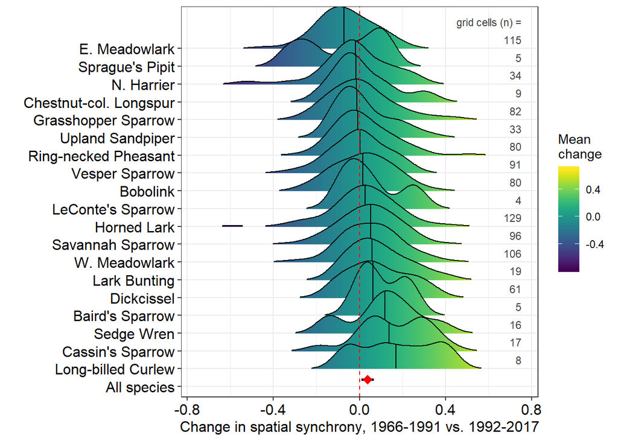

```r
#x11(10,9)
ridgeplotdata %>% mutate(syncdiff = as.numeric(ifelse(species=="All species", NA, syncdiff))) %>%
ggplot(aes(x = syncdiff, y = species, fill = ..x..), fill="gray") +
  geom_density_ridges_gradient(scale = 3, rel_min_height = 0.01, quantile_lines = TRUE, quantiles=2) +
  scale_fill_viridis(name = "Mean\nchange", option = "viridis") +
  labs(x = 'Change in spatial synchrony, 1966-1991 vs. 1992-2017', y = "") +
  annotate("text", x = 0.754, y = (2:21)+0.5,
           label = c(paste0(ridgeplot_sum$n[2:20]),"grid cells (n) ="),
           hjust = 1, color = "gray25", size=3) +
  theme_bw() +
  xlim(c(-0.754,0.754)) +
  geom_vline(aes(xintercept = 0), color="red", linetype = 2) +
  theme(axis.text=element_text(size=12, color = "black"), axis.title=element_text(size=12)) +
  geom_segment(aes(x = allspmean$lcl, y = 1.4, xend = allspmean$ucl, yend = 1.4), color="black", size = 1) +
  geom_point(data=allspmean, aes(x = mean, y = 1.4), color="red", shape = 18, size = 3.5)
```

```r
#ggsave("figures/grid4_maps/ALLsp.grid4_change.ridgeline_AR_5zeros_n20_60latB.png")
```

# Create forest plot of synchrony change by species

Means for each species and bootstrapped confidence intervals.

https://stackoverflow.com/questions/38554383/bootstrapped-confidence-intervals-with-dplyr

Note: should ultimately use “spatial block bootstrapping”: https://sites.google.com/site/halkingwang/programming/r/spatiallycorrelatederrorsspatialblockbootstrappingbagoflittlebootstrapblb

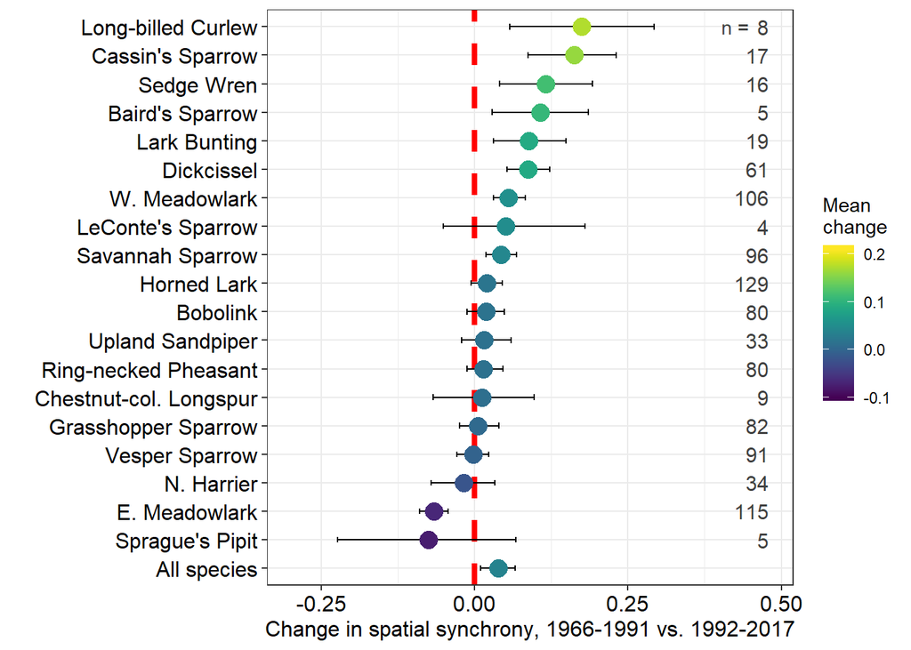

```r
dotplotdata = ridgeplotdata %>%
#  filter(species != "All species") %>%
  group_by(species) %>%
  do(data.frame(rbind(Hmisc::smean.cl.boot(.$syncdiff))))  %>%
  ungroup() %>%
  mutate(mean.order = as.numeric(ifelse(species == "All species","-1",Mean))) %>%
  mutate(species = fct_reorder(species, mean.order, .desc = F)) %>%
  # input overall mean and CI from the linear mixed-effect model intercept
  mutate(Mean = as.numeric(ifelse(species == "All species",allspmean$mean,Mean))) %>%
  mutate(Lower = as.numeric(ifelse(species == "All species",allspmean$lcl,Lower))) %>%
  mutate(Upper = as.numeric(ifelse(species == "All species",allspmean$ucl,Upper)))

dotplot_n = dotplotdata %>%
  left_join(ridgeplot_sum, by = "species") %>%
  dplyr::select(species, Mean, Lower, Upper, n) %>%
  mutate(order = ifelse(species == "All species", -1, Mean)) %>%
  arrange(desc(order)) %>%
  mutate(n = ifelse(species == "All species", "", n))
#x11(10,9)
ggplot(data = dotplotdata) +
  geom_vline(aes(xintercept = 0), color="red", linetype = 2, size = 1.5) +
  geom_errorbarh(aes(xmin = Lower, xmax = Upper, y = species, height = .2)) +
  geom_point(aes(x = Mean, y = species, color = Mean), size = 4.5) +
  scale_color_viridis(name = "Mean\nchange", option = "viridis",limits=c(-.1,.21)) +
  labs(x = 'Change in spatial synchrony, 1966-1991 vs. 1992-2017', y = "") +
  annotate("text", x = 0.48, y = c(20.4,20:1),
           label = c("",paste0(dotplot_n$n[1:20])),
           hjust = 1, color = "gray25", size=4) +
  annotate("text", x = 0.43, y = 20, label = "n = ", color = "gray25") +
  xlim(c(-0.3,0.48)) +
  theme_bw() +
  theme(axis.text=element_text(size=12, color = "black"), axis.title=element_text(size=12,color="black"))
```

```r
#ggsave("figures/grid4_maps/ALLsp.grid4_change.forestplot_AR_5zeros_n20.png")
```

# Data prep for species traits vs. change in syncrhony

Migratory status based on BBS guild classifications: https://www.mbr-pwrc.usgs.gov/bbs/guild/guildlst.html (also used by Zuckerberg et al. 2009) # note: Ring-necked Pheasant is coded as “Short” (it is actually Res) to combine those categories. Trend info from # https://www.mbr-pwrc.usgs.gov/cgi-bin/tf15.pl

```r
traits = dotplot_n %>%
  filter(species != "All species") %>%
  mutate(mig = c("Neo","Short","Short","Neo","Neo","Neo","Short","Short","Short","Short",
                 "Neo","Neo","Short","Short","Neo","Short","Short","Short","Short")) %>%
  mutate(ord = c("non",rep("pas",10),"non","non",rep("pas",3),"non","pas","pas")) %>%
  mutate(firstegg = c("Apr 1-15","Jul 15-31","Jun 1-15","Jun 1-15","May 15-31","May 15-31","May 1-15",
                       "May 15-31","Jun 1-15","Mar 15-31","May 15-31","May 1-15","Apr 15-30",
                       "May 1-15","Jun 1-15","May 1-15","Apr 15-30","May 1-15","May 15-31")) %>%
  mutate(phen = as.factor(c("before 15 May",rep("after 15 May",5),"before 15 May",rep("after 15 May",2),"before 15 May","after 15 May",rep("before 15 May",3),"after 15 May",
                  rep("before 15 May",3),"after 15 May"))) %>%
  mutate(massL = c(640.1, 18.3, 7.73, 17.8, 35.9, 25.2, 89.4, 13, 19.7, 104.4, 28.7, 151,
                    917, 20.3, 17.34, 24.9, 336, 100.1, 23.6)) %>% # avg. mass of the smaller sex (largest n on breeding grounds, BNA); or pooled avg. if sample size larger
  mutate(massU = c(758.6, 18.3, 8.25, 19.1, 38.5, 28.5, 106, 13.2, 19.7, 111.3, 33, 164,
                    1263, 20.3, 18.75, 26.5, 513, 123.2, 23.9)) %>% # avg. mass of the larger sex (largest n on breeding grounds, BNA); or pooled avg. if sample size larger
  mutate(mass = (massL + massU)/2) %>%
  dplyr::select(-massL, -massU) %>%
  mutate(trend.66.15 = c(0.17,-0.75,0.40,-2.17,-2.90,-0.36,-1.29,-2.59,-1.36,-2.46,-2.06,0.40,
                         -0.64,-4.19,-2.52,-0.85,-1.21,-3.28,-3.10)) %>%
  mutate(trend.66.91 = c(-0.40,-0.98,0.07,-1.92,-4.74,-1.04,-1.51,-1.93,-1.63,-2.47,-3.15,0.08,
                         -1.31,-4.56,-2.93,-1.06,-1.83,-3.48,-3.20)) %>%
  mutate(trend.92.15 = c(1.17,-1.21,0.62,-2.39,-1.46,0.18,-1.10,-2.39,-1.27,-2.35,-0.80,0.70,0.02,
                         -4.18,-2.01,-0.67,-1.10,-3.24,-2.18)) %>%
  mutate(trend.change = trend.92.15 - trend.66.91) %>%
  mutate(n = as.numeric(n))

traits$phen = factor(traits$phen,levels(traits$phen)[c(2,1)])
```

# Model set for species-level traits vs. change in synchrony

```r
mass.mod = lm(Mean ~ log(mass), data = traits, weights=n)
mig.mod = lm(Mean ~ mig, data = traits, weights=n)
phen.mod = lm(Mean ~ phen, data = traits, weights=n)
glob.mod = lm(Mean ~ log(mass) + mig + phen, data = traits, weights = n)
null.mod = lm(Mean ~ 1, data = traits, weights=n)

(modcomp = AICc(mass.mod, mig.mod,phen.mod,glob.mod,null.mod))
```

```
##          df      AICc
## mass.mod  3 -45.02469
## mig.mod   3 -44.93026
## phen.mod  3 -47.54805
## glob.mod  5 -40.65944
## null.mod  2 -46.63749
```

# Info for best performing species trait model (phenology):

```r
summary(phen.mod); confint(phen.mod)
```

```
##
## Call:
## lm(formula = Mean ~ phen, data = traits, weights = n)
##
## Weighted Residuals:
##      Min       1Q   Median       3Q      Max
## -0.76622 -0.10552  0.05857  0.22945  0.51134
##
## Coefficients:
##                  Estimate Std. Error t value Pr(>|t|)
## (Intercept)      0.005011   0.013507   0.371   0.7152
## phenafter 15 May 0.041778   0.021659   1.929   0.0706 .
## ---
## Signif. codes:  0 '***' 0.001 '**' 0.01 '*' 0.05 '.' 0.1 ' ' 1
##
## Residual standard error: 0.3322 on 17 degrees of freedom
## Multiple R-squared:  0.1796, Adjusted R-squared:  0.1313
## F-statistic: 3.721 on 1 and 17 DF,  p-value: 0.07061
```

```
##                        2.5 %     97.5 %
## (Intercept)      -0.02348580 0.03350728
## phenafter 15 May -0.00391768 0.08747456
```

# Plot phenology vs. change in synchrony

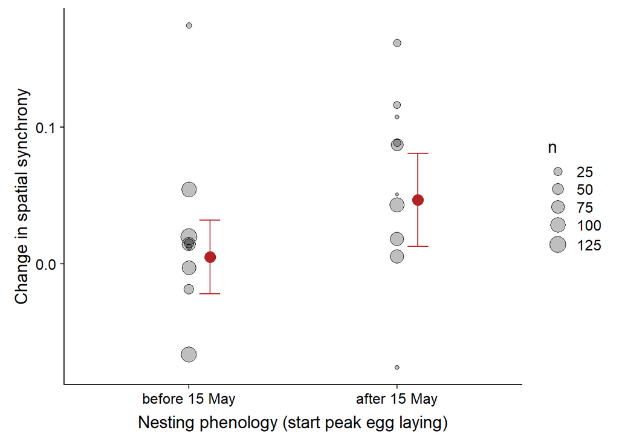

```r
phen.fit =
  data.frame(
  fit = predict(phen.mod, se.fit = T, newdata = data.frame(phen = c("before 15 May","after 15 May")))$fit,
  se = predict(phen.mod, se.fit = T, newdata = data.frame(phen = c("before 15 May","after 15 May")))$se.fit,
  phen = c("before 15 May","after 15 May"),
  type = c(1,2)
  ) %>%
  mutate(fitU = fit + 2*se, fitL = fit - 2*se)

#x11(9,9)
ggplot(traits) +
  geom_point(aes(x=phen, y = Mean, size = as.numeric(n)),shape=16, color="black",alpha = 0.25) +
  geom_point(aes(x=phen, y = Mean, size = as.numeric(n)),shape=1, color="black",alpha = 1) +
  geom_errorbar(data=phen.fit, stat = "identity", aes(x = type+0.1, y=fit, ymin=fitL,ymax=fitU),
                color="firebrick",alpha = 1, width=0.1) +
  geom_point(data=phen.fit, aes(x = type+0.1, y=fit), color="firebrick",size = 4) +
  cowplot::theme_cowplot() +
  labs(size = "n", x = "Nesting phenology (start peak egg laying)", y = "Change in spatial synchrony")
```

```r
#ggsave("species.traits.vs.change.synchrony2.jpg")
```

# Map of mean change in synchrony across species with Moran’s I cluster analysis

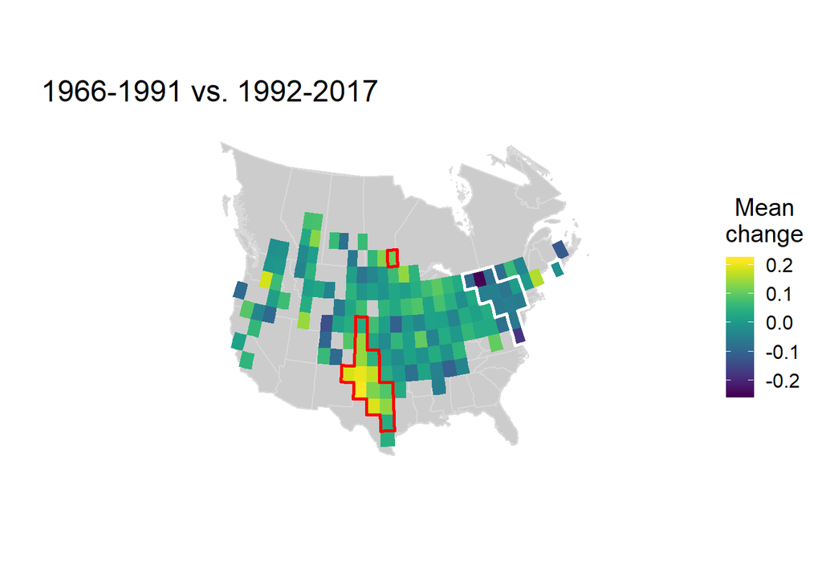

```r
# Make a grid of spatial polygons to match up with meansyncdiff data
rr <- raster::raster(ext = raster::extent(-177, -52, 24, 69), res=c(2,2))
raster::values(rr) <- 1:raster::ncell(rr)
p <- raster::rasterToPolygons(rr)
attributes = tibble(grid4_lon = coordinates(p)[,1], grid4_lat = coordinates(p)[,2]) %>%
  mutate(join = 1, grid.x = paste(trunc(grid4_lat),trunc(grid4_lon),sep="")) %>%
  mutate(grid.x = gsub("-","_",grid.x)) %>%
  left_join(meansyncdiff, by="grid.x")
p$grid = attributes$grid.x
p$meansyncdiff = attributes$meansyncdiff
p$n = attributes$n
p$meandiffcat = attributes$meandiffcat

meansyncdiff.poly = p[is.na(p$n)!=T,]

# Save this as a shapefile?
# writeOGR(meansyncdiff.poly, "C:\\Users\\Mike\\Documents\\Research\\Chapter 3 - Synchrony\\GLBsynchrony\\data", "meansyncdiff_poly", driver="ESRI Shapefile")

meansyncdiff.data = fortify(meansyncdiff.poly, region = "grid") %>%
  left_join(rename(meansyncdiff.poly@data, id=grid),by = "id")

#x11(13,9)
na + geom_polygon(data=meansyncdiff.data, aes(x=long, y = lat, group=group, fill = meansyncdiff)) +
  scale_fill_viridis(name = "Mean\nchange", option = "viridis") +
  theme_classic() +
  theme(text = element_text(size=15)) +
  labs(colour="Change in\nmean spatial\nsynchrony", x="", y="", title="1966-1991 vs. 1992-2017") +
  theme(axis.text.x = element_blank(),  axis.text.y = element_blank(),axis.ticks = element_blank()) +
  theme(legend.title.align=0.5) +
  theme(axis.line = element_line(color = "transparent")) +
  xlim(c(-142,-59)) +
  geom_polygon(data = clust.inc_fort, aes(x = long, y = lat, group=group), color = "red",fill="transparent",size=1) +
  geom_polygon(data = clust.dec_fort, aes(x = long, y = lat, group=group), color = "white",fill="transparent",size=1)
```

```r
#ggsave("figures/grid4_maps/Mean.ALLsp.grid4_change.viridis.poly_AR_5zeros_n20_60lat.png")
```

# Leaflet map of cluster plus grid of mean change in synchrony across species

```r
#qpal<-colorQuantile("OrRd", exp(g@data$strata)-1, n=9)
#qpal = colorFactor("OrRd",clusters@data$LISA_CL)

bins <- c(-1, 0, .10, .20, .30, .4, .5, Inf)
pal <- colorBin("YlOrRd", domain = meansyncdiff.poly$meansyncdiff, bins = bins)

leaflet() %>%
  addPolygons(data=meansyncdiff.poly, stroke = T, fillColor = ~pal(meansyncdiff),
              fillOpacity = .5, smoothFactor = 0.2, opacity = 1, color = "white", weight = 2, dashArray = 3) %>%
  addPolygons(data=clust.inc, stroke = T, fillOpacity = 0, smoothFactor = 0.2, color = "red") %>%
  addTiles()
```

[interactive chart not shown]

# Which species contribute to main increasing synchrony cluster?

Make a list of the 13 grid cells in the increasing cluster. Then count the number of grid cells (out of 13) occupied by each species.

```r
# make list of cells in increasing cluster
grid_inc = data.frame(grid=unique(filter(cluster_fort, LISA_CL==1)$id)) %>%
  filter(grid != "50_96") # exclude the single-cell cluster

# count the number of grid cells (out of 13) occupied by each species
who_inc_data = syncdiff %>%
  filter(grid.x %in% grid_inc$grid)

(who_inc = who_inc_data %>%
  group_by(sp.x) %>%
  summarise(contribution = length(sp.x), med = median(syncdiff)) %>%
  arrange(desc(contribution)))
```

```
## # A tibble: 12 x 3
##    sp.x  contribution     med
##    <fct>        <int>   <dbl>
##  1 HOLA            10  0.0390
##  2 CASP            10  0.248
##  3 WEME            10  0.226
##  4 DICK             9  0.194
##  5 GRSP             7  0.252
##  6 EAME             7  0.0247
##  7 RNEP             6 -0.0117
##  8 LARB             5  0.221
##  9 NOHA             2 -0.138
## 10 BOBO             1 -0.252
## 11 UPSA             1 -0.0916
## 12 LBCU             1  0.398
```

# Which species contribute to main decreasing synchrony cluster?

```r
# make a list of the 13 grid cells in that cluster
grid_dec = data.frame(grid=unique(filter(cluster_fort, LISA_CL==2)$id)) %>%
  filter(grid != "44_66")
# count the number of grid cells (out of 12) occupied by each species
who_dec_data = syncdiff %>%
  filter(grid.x %in% grid_dec$grid)

(who_dec = who_dec_data %>%
  group_by(sp.x) %>%
  summarise(contribution = length(sp.x), med = median(syncdiff)) %>%
  arrange(desc(contribution)))
```

```
## # A tibble: 9 x 3
##   sp.x  contribution     med
##   <fct>        <int>   <dbl>
## 1 EAME            12 -0.0769
## 2 BOBO            11  0.0149
## 3 SAVS            10 -0.0847
## 4 VESP             8 -0.112
## 5 GRSP             6 -0.158
## 6 HOLA             6 -0.113
## 7 RNEP             5 -0.0706
## 8 UPSA             2 -0.0268
## 9 NOHA             1 -0.161
```

# Graph of synchrony changes in increasing and decreasing clusters (dotplots, facets)

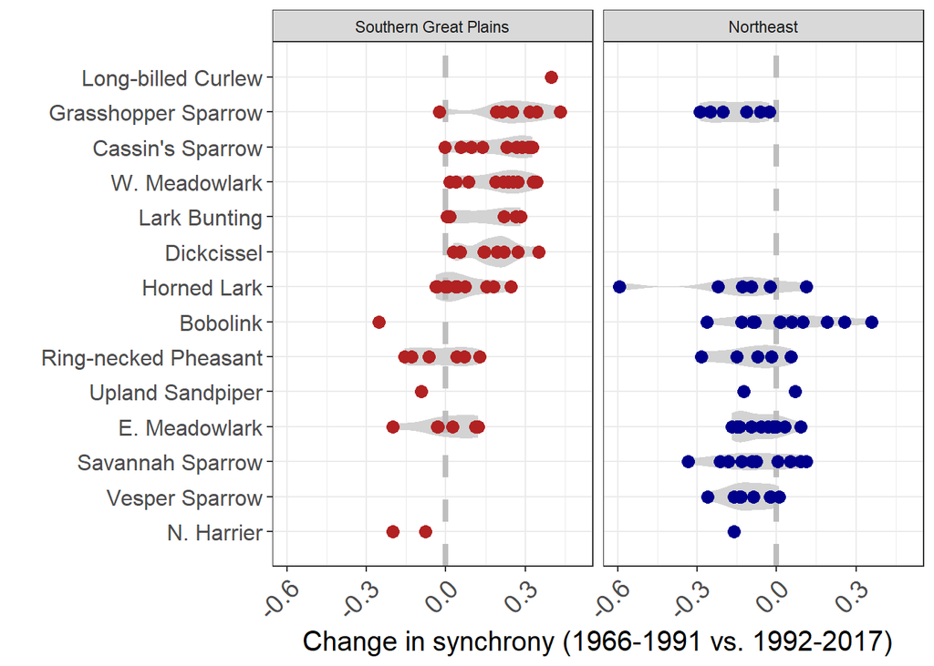

```r
# data for plot: syncdiff within the Semiarid Prairies increasing cluster by species
inc_plot = who_inc_data %>%
  left_join(who_inc, by = "sp.x") %>%
  mutate(sp.x = fct_reorder(sp.x, med, .desc = T))

# data for plot: syncdiff within the Northeast decreasing cluster by species
dec_plot = who_dec_data %>%
  left_join(who_dec, by = "sp.x") %>%
  mutate(sp.x = fct_reorder(sp.x, med, .desc = T))

incdec_plot = bind_rows(inc_plot,dec_plot) %>%
  mutate(cluster = c(rep("SGP",69), rep("NE", 61))) %>%
  mutate(cluster = fct_reorder(cluster, c(rep(1,69),rep(2,61))),desc=T)

incdec_plot2 = droplevels(incdec_plot) %>%
  mutate(cluster = c(rep("Southern Great Plains",69), rep("Northeast", 61))) %>%
  mutate(cluster = fct_reorder(cluster, c(rep(1,69),rep(2,61))),desc=T)

levels(incdec_plot2$sp.x) =
  rev(c("Vesper Sparrow","Savannah Sparrow","Bobolink",
        "N. Harrier","Upland Sandpiper","Ring-necked Pheasant",
        "E. Meadowlark","Horned Lark","Dickcissel",
        "Lark Bunting", "W. Meadowlark","Cassin's Sparrow",
        "Grasshopper Sparrow","Long-billed Curlew"))

#x11(10,9)
incdec_plot2 %>%
  mutate(sp.x = fct_reorder(sp.x, med)) %>%
ggplot() +
  geom_violin(aes(y = syncdiff, x = sp.x),fill="lightgray",color="transparent") +
  coord_flip() +
  geom_segment(aes(y = 0, x = 0, xend = 15, yend = 0),
               color = "gray", size = 1.5, linetype = 2) +
  geom_point(aes(y = syncdiff, x = sp.x, color = cluster),size=3) +
  facet_wrap(~cluster) +
  labs(y = "Change in synchrony (1966-1991 vs. 1992-2017)",
       x = "") +
  #cowplot::theme_cowplot() +
  theme_bw() +
  theme(axis.text.x = element_text(size=14, angle = 45, hjust=1),
        axis.text.y = element_text(size=12),
        axis.title.y = element_text(size = 15),
        axis.title.x = element_text(size = 15)) +
  scale_y_continuous(limits = c(-0.6,0.5)) +
  scale_color_manual(values = c("firebrick","darkblue")) +
  theme(legend.position = "none")
```

```r
#ggsave("figures/pub_figs/contributions_facet.jpg")
```

# Cross-synchrony of 6 main contributing species within the increasing SGP hotspot

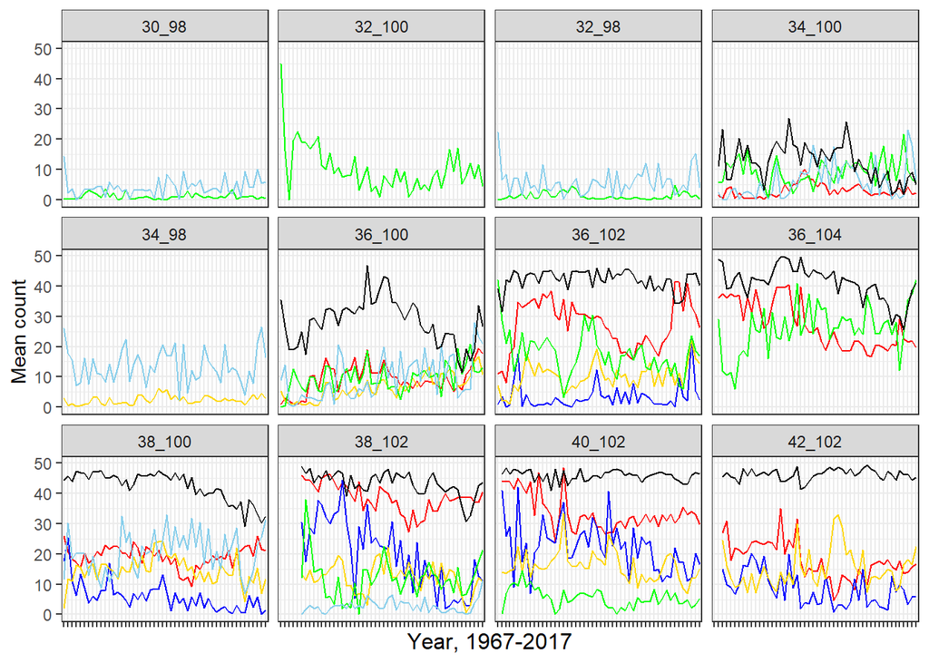

```r
# Data were preloaded as cross.data.Rdata; run next line only if needed (takes a while)
# source("scripts/SGP_cross_data.R") #

sgp.data = cross.data %>%
  filter(year != 1967) %>%
  dplyr::select(grid = grid4, year, GRSP = GRSP.meancount, CASP = CASP.meancount, WEME = WEME.meancount, LARB = LARB.meancount, HOLA = HOLA.meancount, DICK = DICK.meancount)

#write.csv(sgp.data, "sgp.bird.data.csv")

sgp.data %>%
  ggplot() +
  geom_line(aes(x = year, y = HOLA, group = grid), color = "red") +
  geom_line(aes(x = year, y = LARB, group = grid), color = "blue") +
  geom_line(aes(x = year, y = GRSP, group = grid), color = "gold") +
  geom_line(aes(x = year, y = CASP, group = grid), color = "green") +
  geom_line(aes(x = year, y = DICK, group = grid), color = "skyblue") +
  geom_line(aes(x = year, y = WEME, group = grid), color = "black") +
  facet_wrap(~grid) +
  labs(y = "Mean count", x = "Year, 1967-2017") +
  theme_bw() +
  theme(axis.title.x=element_text(size = 12),
        axis.text.x=element_blank())
```

# Make a function to average data by year for all shared SGP cells for pairwise cross-correlations

```r
crosssync = function(sp1,sp2, yearstart, yearend){#sp1="DICK"; sp2="LARB"; yearstart = 1992; yearend = 2017
sp1 = enquo(sp1)
sp2 = enquo(sp2)
pair = paste0(quo_name(sp1),".",quo_name(sp2))
cor.format = cross.data %>%
  filter(year>=yearstart, year<=yearend) %>%
  drop_na(!!sp1, !!sp2) %>%
  group_by(year) %>%
  summarise(n = length(grid4), mean1 := mean(!!sp1), mean2 := mean(!!sp2)) %>%
  ungroup() %>%
  mutate(pair = !!pair)
return(cor.format)
}
```

# Gather together the 66-91 population data from SGP and run correlations

```r
crosssync.data.66.91 = bind_rows(
  crosssync(GRSP.ar, CASP.ar, 1966, 1991),
  crosssync(GRSP.ar, WEME.ar, 1966, 1991),
  crosssync(GRSP.ar, LARB.ar, 1966, 1991),
  crosssync(GRSP.ar, DICK.ar, 1966, 1991),
  crosssync(GRSP.ar, HOLA.ar, 1966, 1991),
  crosssync(CASP.ar, WEME.ar, 1966, 1991),
  crosssync(CASP.ar, LARB.ar, 1966, 1991),
  crosssync(CASP.ar, DICK.ar, 1966, 1991),
  crosssync(CASP.ar, HOLA.ar, 1966, 1991),
  crosssync(WEME.ar, LARB.ar, 1966, 1991),
  crosssync(WEME.ar, DICK.ar, 1966, 1991),
  crosssync(WEME.ar, HOLA.ar, 1966, 1991),
  crosssync(LARB.ar, DICK.ar, 1966, 1991),
  crosssync(LARB.ar, HOLA.ar, 1966, 1991),
  crosssync(HOLA.ar, DICK.ar, 1966, 1991)
)

(
  crosssync.sum.66.91 =
    crosssync.data.66.91 %>%
    group_by(pair) %>%
    summarise(
      r = cor.test(mean1, mean2)$estimate,
      lcl = cor.test(mean1, mean2)$conf.int[1],
      ucl = cor.test(mean1, mean2)$conf.int[2],
      p = cor.test(mean1, mean2)$p.value,
      n = mean(n)
    ) %>%
    ungroup()
)
```

```
## # A tibble: 15 x 6
##    pair                  r    lcl     ucl      p     n
##    <chr>             <dbl>  <dbl>   <dbl>  <dbl> <dbl>
##  1 CASP.ar.DICK.ar -0.321  -0.642  0.0943 0.126   4.79
##  2 CASP.ar.HOLA.ar  0.273  -0.146  0.609  0.196   5.71
##  3 CASP.ar.LARB.ar -0.422  -0.705 -0.0223 0.0400  2.79
##  4 CASP.ar.WEME.ar -0.161  -0.530  0.259  0.452   5.71
##  5 GRSP.ar.CASP.ar -0.226  -0.577  0.195  0.288   3.79
##  6 GRSP.ar.DICK.ar  0.214  -0.207  0.568  0.316   3.83
##  7 GRSP.ar.HOLA.ar -0.0447 -0.440  0.365  0.836   5.71
##  8 GRSP.ar.LARB.ar  0.303  -0.114  0.630  0.150   4.71
##  9 GRSP.ar.WEME.ar  0.507   0.130  0.756  0.0115  5.71
## 10 HOLA.ar.DICK.ar  0.146  -0.273  0.519  0.495   3.79
## 11 LARB.ar.DICK.ar  0.154  -0.266  0.525  0.472   1.83
## 12 LARB.ar.HOLA.ar -0.0104 -0.412  0.395  0.961   4.71
## 13 WEME.ar.DICK.ar  0.117  -0.300  0.497  0.585   3.79
## 14 WEME.ar.HOLA.ar -0.155  -0.525  0.265  0.470   7.62
## 15 WEME.ar.LARB.ar  0.0764 -0.337  0.465  0.723   4.71
```

# Gather together the 92-17 population data from SGP and run correlations

```r
crosssync.data.92.17 = bind_rows(
  crosssync(GRSP.ar, CASP.ar, 1992, 2017),
  crosssync(GRSP.ar, WEME.ar, 1992, 2017),
  crosssync(GRSP.ar, LARB.ar, 1992, 2017),
  crosssync(GRSP.ar, DICK.ar, 1992, 2017),
  crosssync(GRSP.ar, HOLA.ar, 1992, 2017),
  crosssync(CASP.ar, WEME.ar, 1992, 2017),
  crosssync(CASP.ar, LARB.ar, 1992, 2017),
  crosssync(CASP.ar, DICK.ar, 1992, 2017),
  crosssync(CASP.ar, HOLA.ar, 1992, 2017),
  crosssync(WEME.ar, LARB.ar, 1992, 2017),
  crosssync(WEME.ar, DICK.ar, 1992, 2017),
  crosssync(WEME.ar, HOLA.ar, 1992, 2017),
  crosssync(LARB.ar, DICK.ar, 1992, 2017),
  crosssync(LARB.ar, HOLA.ar, 1992, 2017),
  crosssync(HOLA.ar, DICK.ar, 1992, 2017)
)

(
  crosssync.sum.92.17 =
    crosssync.data.92.17 %>%
    group_by(pair) %>%
    summarise(
      r = cor.test(mean1, mean2)$estimate,
      lcl = cor.test(mean1, mean2)$conf.int[1],
      ucl = cor.test(mean1, mean2)$conf.int[2],
      p = cor.test(mean1, mean2)$p.value,
      n = mean(n)
    ) %>%
    ungroup()
)
```

```
## # A tibble: 15 x 6
##    pair                  r     lcl     ucl         p     n
##    <chr>             <dbl>   <dbl>   <dbl>     <dbl> <dbl>
##  1 CASP.ar.DICK.ar -0.532  -0.763  -0.183  0.00511       5
##  2 CASP.ar.HOLA.ar -0.0446 -0.425   0.349  0.829         6
##  3 CASP.ar.LARB.ar -0.506  -0.747  -0.147  0.00838       3
##  4 CASP.ar.WEME.ar -0.440  -0.707  -0.0636 0.0244        6
##  5 GRSP.ar.CASP.ar -0.267  -0.593   0.134  0.187         4
##  6 GRSP.ar.DICK.ar  0.732   0.481   0.872  0.0000216     4
##  7 GRSP.ar.HOLA.ar -0.362  -0.657   0.0295 0.0692        6
##  8 GRSP.ar.LARB.ar  0.339  -0.0552  0.642  0.0898        5
##  9 GRSP.ar.WEME.ar  0.432   0.0538  0.702  0.0275        6
## 10 HOLA.ar.DICK.ar  0.142  -0.260   0.502  0.489         4
## 11 LARB.ar.DICK.ar  0.490   0.127   0.737  0.0110        2
## 12 LARB.ar.HOLA.ar -0.256  -0.585   0.146  0.207         5
## 13 WEME.ar.DICK.ar  0.599   0.276   0.801  0.00122       4
## 14 WEME.ar.HOLA.ar -0.148  -0.506   0.254  0.472         8
## 15 WEME.ar.LARB.ar  0.277  -0.123   0.600  0.170         5
```

# Plot time series of contributing species in the increasing hot-spot

## e.g., GRSP vs. Dickcissel

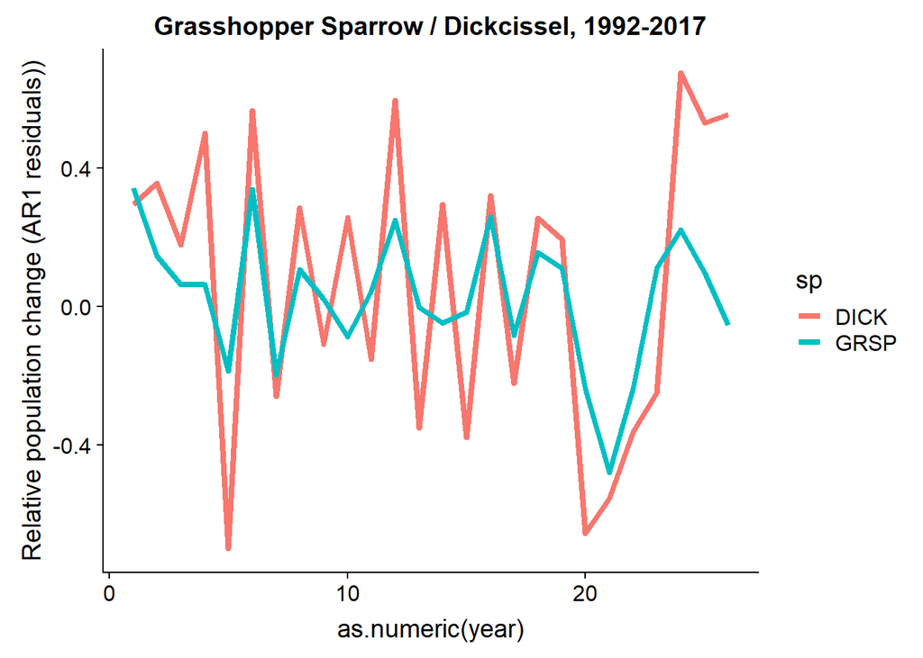

```r
#x11(17,9)
gd=crosssync(GRSP.ar,DICK.ar,1992,2017)
gdlong = data.frame(pop = c(gd$mean1,gd$mean2), sp = c(rep("GRSP",26),rep("DICK",26)), year = c(gd$year,gd$year))
ggplot(gdlong) +
  geom_line(aes(x = as.numeric(year), y = pop, color=sp), size = 1.5) +
  geom_line(aes(x = as.numeric(year), y = pop, color=sp), size = 1.5) +
    cowplot::theme_cowplot() +
  labs(title = "Grasshopper Sparrow / Dickcissel, 1992-2017", y = "Relative population change (AR1 residuals))")
```

```r
#ggsave("GRSP_DICK_ts_increasing_cluster_1992-2017.jpg")
```

# Make maps and shapefiles of bird grids if needed

```r
#grsp.map = bbsync("5460", 1992, 2017, "AR", "grid.map")
#plot(grsp.map, col = "gray")
# writeOGR(grsp.map, "C:\\Users\\Mike\\Documents\\Research\\Chapter 3 - Synchrony\\GLBsynchrony\\data", "grsp_grid4_poly_lamb.92.17", driver="ESRI Shapefile")

#bobo.map = bbsync("4940", 1992, 2017, "AR", "grid.map")
#plot(bobo.map, col = "gray")
# writeOGR(bobo.map, "C:\\Users\\Mike\\Documents\\Research\\Chapter 3 - Synchrony\\GLBsynchrony\\data", "bobo_grid4_poly_lamb.92.17", driver = "ESRI Shapefile")

#eame.map = bbsync("5010",1992,2017,"AR","grid.map"); x11(13,9); plot(eame.map,col="gray")
# writeOGR(eame.map, "C:\\Users\\Mike\\Documents\\Research\\Chapter 3 - Synchrony\\GLBsynchrony\\data", "eame_grid4_poly_lamb.92.17", driver="ESRI Shapefile")

#savs.map = bbsync("5420",1992,2017,"AR","grid.map"); x11(13,9); plot(savs.map,col="gray")
# writeOGR(savs.map, "C:\\Users\\Mike\\Documents\\Research\\Chapter 3 - Synchrony\\GLBsynchrony\\data", "savs_grid4_poly_lamb.92.17", driver="ESRI Shapefile")

#casp.map = bbsync("5780",1992,2017,"AR","grid.map"); x11(13,9); plot(savs.map,col="gray")
# writeOGR(savs.map, "C:\\Users\\Mike\\Documents\\Research\\Chapter 3 - Synchrony\\GLBsynchrony\\data", "casp_grid4_poly_lamb.92.17", driver="ESRI Shapefile")
```

# Links to data sources, code, papers, etc.

1. List of grassland bird species: https://www.mbr-pwrc.usgs.gov/bbs/grass/actlist.htm
2. BBS Route-level data fields: ftp://ftpext.usgs.gov/pub/er/md/laurel/BBS/DataFiles/Summary.txt
3. BBS RouteID info: ftp://ftpext.usgs.gov/pub/er/md/laurel/BBS/DataFiles/RegionCodes.txt
4. BBS phys strata map: https://www.pwrc.usgs.gov/bbs/StrataNames/strata_map_small.htm
5. BBS Route info txt with BCR and strata codes: ftp://ftpext.usgs.gov/pub/er/md/laurel/BBS/DataFiles/RouteInf.txt
6. BBS BCR shapefile: http://www.pwrc.usgs.gov/bba/index.cfm?fa=bba.getdata
7. Smith et al. sup data for CAR model and indices of aerial insectivores: https://journals.plos.org/plosone/article?id=10.1371/journal.pone.0130768#sec016 https://journals.plos.org/plosone/article/file?id=10.1371/journal.pone.0130768.s005&type=supplementary
8. Michel et al. README file: https://datadryad.org/bitstream/handle/10255/dryad.96773/README.txt?sequence=2
9. Michel et al. paper with link to sup code files: https://onlinelibrary.wiley.com/doi/abs/10.1111/ecog.01798